# Lab 8.5 - Annotations and text

So far we have covered most of the basic tools we need to produce a nice plot. We are just lacking some final touches.

# Annotations with `geoms`

Perhaps you noticed that, even though we mentioned it at the begining of the visualization block, the `geom_text` (and similar geoms) weren’t used so far.

There is a good reason for that. The main one is that normally we add annotations and labels once we have a version of the plot close to be final.

Adding labels as geoms works no different from any other geom. Actually, we may think of `geom_text` as `geom_point` to which we add a label instead of color or shape. Take a look on how we add two text layers with the year of the top four BA and N:

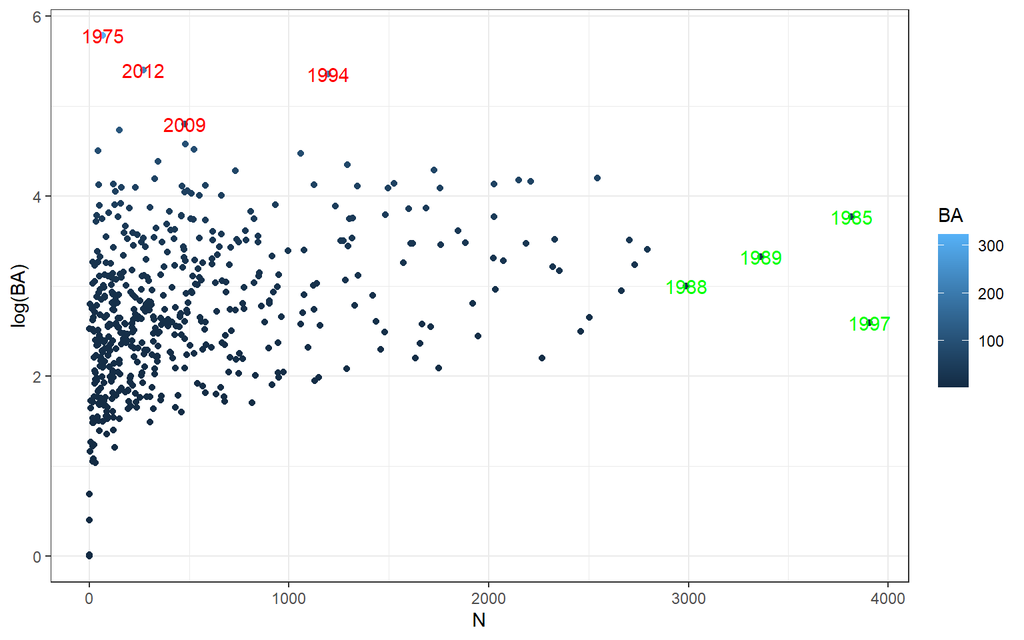

```r
ba <- fires %>%
    group_by(MONTH, YEAR) %>%
    summarise(BA = mean(BAREA), N = n()) %>%
    ungroup() %>%
    arrange(desc(BA)) %>%
    head(4)

n <- fires %>%
    group_by(MONTH, YEAR) %>%
    summarise(BA = mean(BAREA), N = n()) %>%
    ungroup() %>%
    arrange(desc(N)) %>%
    head(4)

fires %>%
    group_by(MONTH, YEAR) %>%
    summarise(BA = mean(BAREA), N = n()) %>%
    ggplot() + geom_point(aes(x = N, y = log(BA), color = BA)) + geom_text(data = ba,
    aes(x = N, y = log(BA), label = YEAR), color = "red") + geom_text(data = n, aes(x = N,
    y = log(BA), label = YEAR), color = "green") + theme_bw()
```

## Preventing overlapping

That was easy but there are obvious problems. Labels overlap points and can potentially overlap each other. There are several ways to prevent these issues. For instance, we can use `nudge_x` and `nudge_y` to reposition the label keeping points as reference. Note how red labels move to a location next to the points.

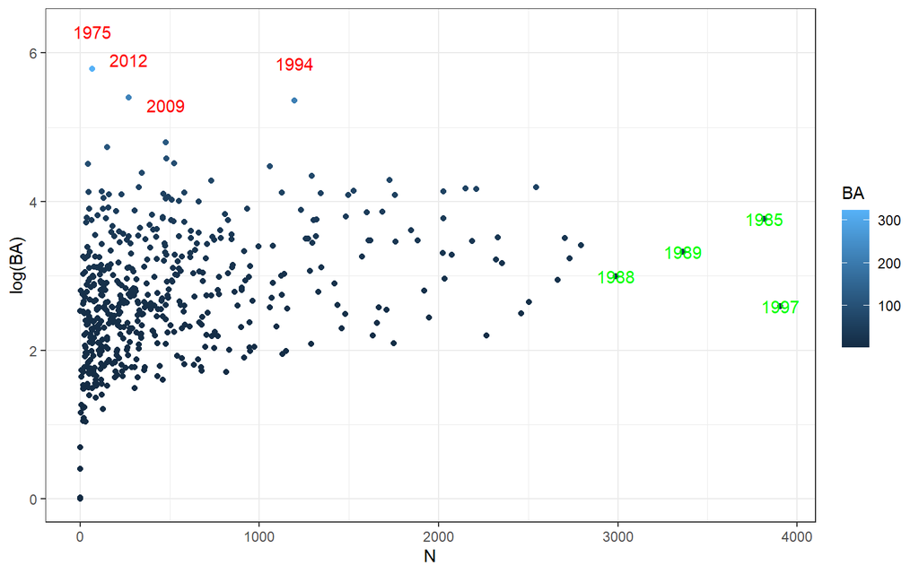

```r
ba <- fires %>%
    group_by(MONTH, YEAR) %>%
    summarise(BA = mean(BAREA), N = n()) %>%
    ungroup() %>%
    arrange(desc(BA)) %>%
    head(4)

n <- fires %>%
    group_by(MONTH, YEAR) %>%
    summarise(BA = mean(BAREA), N = n()) %>%
    ungroup() %>%
    arrange(desc(N)) %>%
    head(4)

fires %>%
    group_by(MONTH, YEAR) %>%
    summarise(BA = mean(BAREA), N = n()) %>%
    ggplot() + geom_point(aes(x = N, y = log(BA), color = BA)) + geom_text(data = ba,
    aes(x = N, y = log(BA), label = YEAR), color = "red", nudge_x = 0.5, nudge_y = 0.5) +
    geom_text(data = n, aes(x = N, y = log(BA), label = YEAR), color = "green") +
    theme_bw()
```

But perhaps the best way to prevent overlapping is by means of package `ggrepel` built to provide funtionalitys that automatically place and style annotations. `ggrepel` extends the basic functionality of `ggplot` by adding **specific geoms**, `geom_text_repel` or `geom_label_repel`.

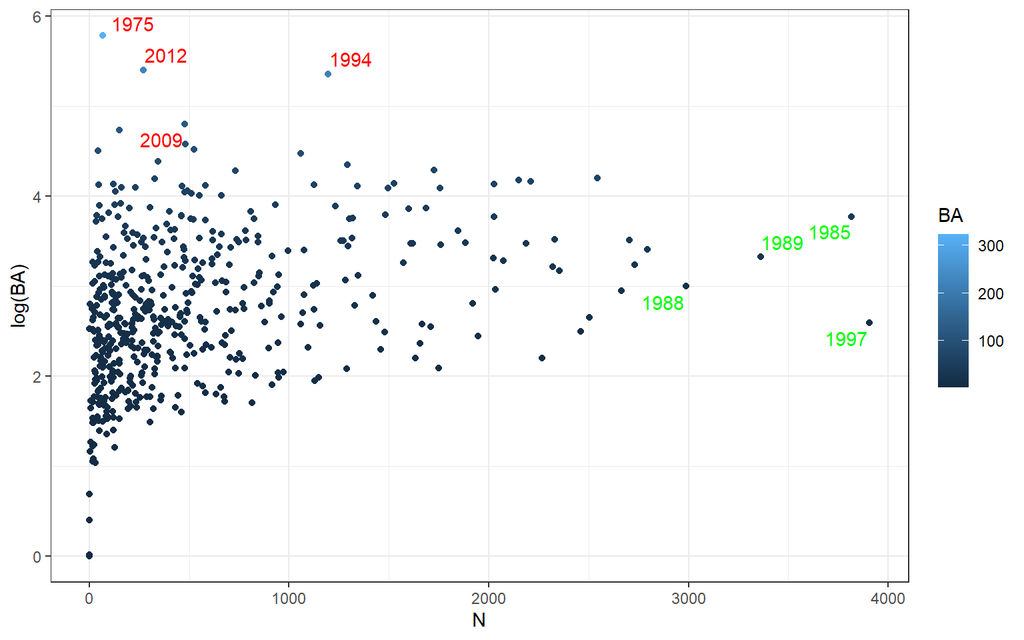

```r
library(ggrepel)

ba <- fires %>%
    group_by(MONTH, YEAR) %>%
    summarise(BA = mean(BAREA), N = n()) %>%
    ungroup() %>%
    arrange(desc(BA)) %>%
    head(4)

n <- fires %>%
    group_by(MONTH, YEAR) %>%
    summarise(BA = mean(BAREA), N = n()) %>%
    ungroup() %>%
    arrange(desc(N)) %>%
    head(4)

fires %>%
    group_by(MONTH, YEAR) %>%
    summarise(BA = mean(BAREA), N = n()) %>%
    ggplot() + geom_point(aes(x = N, y = log(BA), color = BA)) + geom_text_repel(data = ba,
    aes(x = N, y = log(BA), label = YEAR), color = "red") + geom_text_repel(data = n,
    aes(x = N, y = log(BA), label = YEAR), color = "green") + theme_bw()
```

An the same works for `geom_label_repel`, but notice that in this case a line/arrow is automatically drawn, linking points and labels:

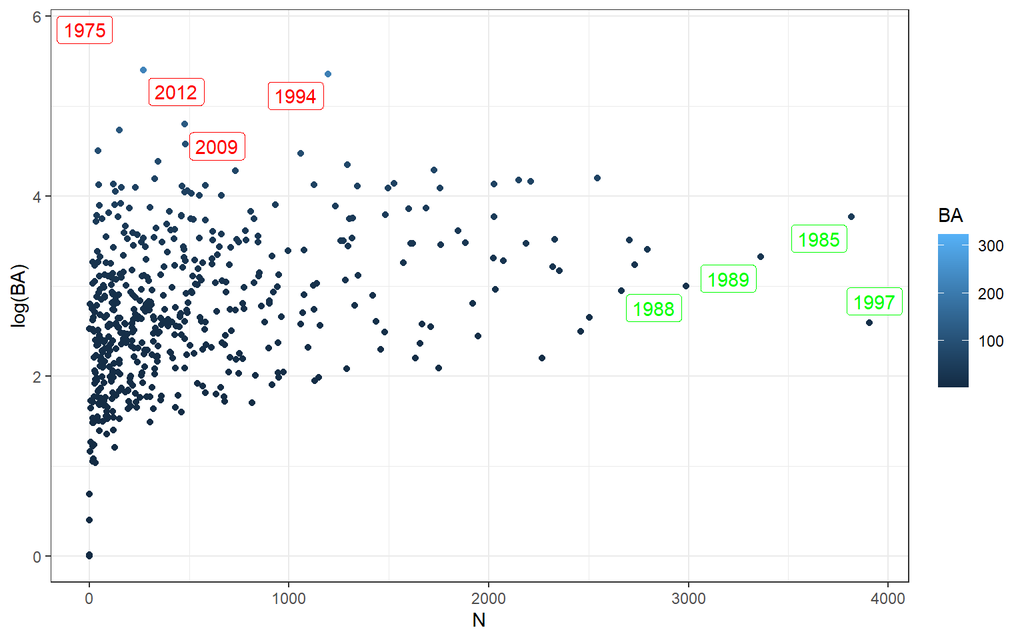

```r
library(ggrepel)

ba <- fires %>%
    group_by(MONTH, YEAR) %>%
    summarise(BA = mean(BAREA), N = n()) %>%
    ungroup() %>%
    arrange(desc(BA)) %>%
    head(4)

n <- fires %>%
    group_by(MONTH, YEAR) %>%
    summarise(BA = mean(BAREA), N = n()) %>%
    ungroup() %>%
    arrange(desc(N)) %>%
    head(4)

fires %>%
    group_by(MONTH, YEAR) %>%
    summarise(BA = mean(BAREA), N = n()) %>%
    ggplot() + geom_point(aes(x = N, y = log(BA), color = BA)) + geom_label_repel(data = ba,
    aes(x = N, y = log(BA), label = YEAR), color = "red") + geom_label_repel(data = n,
    aes(x = N, y = log(BA), label = YEAR), color = "green") + theme_bw()
```